# Data Visualisation of Ford GoBike System Data

## Introduction

> This project involves the use of Python visualization libraries to systematically explore the `Ford GoBike System`, using univariate, bivariate and multivariate plots to convey insight.

## Preliminary Wrangling

```python
# import all packages and set plots to be embedded inline
import numpy as np
import pandas as pd
import matplotlib.pyplot as plt
import seaborn as sb


%matplotlib inline
```

#### Data Assessing

The data is assessed for any quality or tidiness issue.

```python
# Loading the dataset and viewing the first 5 rows
df = pd.read_csv('2017-fordgobike-tripdata.csv')
df.head()
```

|  | duration_sec | start_time | end_time | start_station_id | start_station_name | start_station_latitude | start_station_longitude | end_station_id | end_station_name | end_station_latitude | end_station_longitude | bike_id | user_type |
| --- | --- | --- | --- | --- | --- | --- | --- | --- | --- | --- | --- | --- | --- |
| 0 | 80110 | 2017-12-31 16:57:39.6540 | 2018-01-01 15:12:50.2450 | 74 | Laguna St at Hayes St | 37.776435 | -122.426244 | 43 | San Francisco Public Library (Grove St at Hyde... | 37.778768 | -122.415929 | 96 | Customer |
| 1 | 78800 | 2017-12-31 15:56:34.8420 | 2018-01-01 13:49:55.6170 | 284 | Yerba Buena Center for the Arts (Howard St at ... | 37.784872 | -122.400876 | 96 | Dolores St at 15th St | 37.766210 | -122.426614 | 88 | Customer |
| 2 | 45768 | 2017-12-31 22:45:48.4110 | 2018-01-01 11:28:36.8830 | 245 | Downtown Berkeley BART | 37.870348 | -122.267764 | 245 | Downtown Berkeley BART | 37.870348 | -122.267764 | 1094 | Customer |
| 3 | 62172 | 2017-12-31 17:31:10.6360 | 2018-01-01 10:47:23.5310 | 60 | 8th St at Ringold St | 37.774520 | -122.409449 | 5 | Powell St BART Station (Market St at 5th St) | 37.783899 | -122.408445 | 2831 | Customer |
| 4 | 43603 | 2017-12-31 14:23:14.0010 | 2018-01-01 02:29:57.5710 | 239 | Bancroft Way at Telegraph Ave | 37.868813 | -122.258764 | 247 | Fulton St at Bancroft Way | 37.867789 | -122.265896 | 3167 | Subscriber |

```python
df.describe()
```

|  | duration_sec | start_station_id | start_station_latitude | start_station_longitude | end_station_id | end_station_latitude | end_station_longitude | bike_id |
| --- | --- | --- | --- | --- | --- | --- | --- | --- |
| count | 519700.000000 | 519700.000000 | 519700.000000 | 519700.000000 | 519700.000000 | 519700.000000 | 519700.000000 | 519700.000000 |
| mean | 1099.009521 | 95.034245 | 37.771653 | -122.363927 | 92.184041 | 37.771844 | -122.363236 | 1672.533079 |
| std | 3444.146451 | 86.083078 | 0.086305 | 0.105573 | 84.969491 | 0.086224 | 0.105122 | 971.356959 |
| min | 61.000000 | 3.000000 | 37.317298 | -122.444293 | 3.000000 | 37.317298 | -122.444293 | 10.000000 |
| 25% | 382.000000 | 24.000000 | 37.773492 | -122.411726 | 23.000000 | 37.774520 | -122.410345 | 787.000000 |
| 50% | 596.000000 | 67.000000 | 37.783521 | -122.398870 | 66.000000 | 37.783830 | -122.398525 | 1728.500000 |
| 75% | 938.000000 | 139.000000 | 37.795392 | -122.391034 | 134.000000 | 37.795392 | -122.391034 | 2520.000000 |
| max | 86369.000000 | 340.000000 | 37.880222 | -121.874119 | 340.000000 | 37.880222 | -121.874119 | 3733.000000 |

```python
df.dtypes
```

```
duration_sec                 int64
start_time                  object
end_time                    object
start_station_id             int64
start_station_name          object
start_station_latitude     float64
start_station_longitude    float64
end_station_id               int64
end_station_name            object
end_station_latitude       float64
end_station_longitude      float64
bike_id                      int64
user_type                   object
dtype: object
```

```python
df.info()
```

```
<class 'pandas.core.frame.DataFrame'>
RangeIndex: 519700 entries, 0 to 519699
Data columns (total 13 columns):
 #   Column                   Non-Null Count   Dtype
---  ------                   --------------   -----
 0   duration_sec             519700 non-null  int64
 1   start_time               519700 non-null  object
 2   end_time                 519700 non-null  object
 3   start_station_id         519700 non-null  int64
 4   start_station_name       519700 non-null  object
 5   start_station_latitude   519700 non-null  float64
 6   start_station_longitude  519700 non-null  float64
 7   end_station_id           519700 non-null  int64
 8   end_station_name         519700 non-null  object
 9   end_station_latitude     519700 non-null  float64
 10  end_station_longitude    519700 non-null  float64
 11  bike_id                  519700 non-null  int64
 12  user_type                519700 non-null  object
dtypes: float64(4), int64(4), object(5)
memory usage: 41.6+ MB
```

##### Quality Issues

> The following quality issues were observed after assesssing the dataset
> - There are no null values present in any row.
> - Datatype for start and end time are object types instead of datetime.
> - The datetime for bike id, start and end station id are integers.
> - Day, month and time are in the same column for start and end time

#### Data Cleaning

```python
# convert datatype of bike id, start and end station ids from integer to strings

df.bike_id = df.bike_id.astype(str)
df.start_station_id = df.start_station_id.astype(str)
df.end_station_id = df.end_station_id.astype(str)
```

```python
# Convert start and endtime columns to datetime datatype

df.start_time = pd.to_datetime(df.start_time)
df.end_time = pd.to_datetime(df.end_time)
```

```python
# Extracting days of the week, months and hour from the start and end time columns

from datetime import datetime as dt
df['start_day'] = df.start_time.dt.strftime("%A")
df['start_month'] = df.start_time.dt.strftime("%B")
df['start_hour'] = df.start_time.dt.strftime("%H")
```

```python
# convert start_day, start_month, and start_hour into ordered categorical types

ordinal_var_dict = {'start_day': ['Sunday','Monday','Tuesday','Wednesday','Thursday', 'Friday', 'Saturday'],
                    'start_month': ['January', 'February', 'March', 'April', 'May', 'June', 'July', 'August', 'September', 'October', 'November', 'December'],
                    'start_hour': ['01', '02', '03', '04', '05', '06', '07', '08', '09', '10', '11', '12', '13', '14', '15', '16', '17', '18', '19', '20', '21', '22', '23', '24']}

for var in ordinal_var_dict:
    ordered_var = pd.api.types.CategoricalDtype(ordered = True,
                                                categories = ordinal_var_dict[var])
    df[var] = df[var].astype(ordered_var)
```

```python
df.info()
```

```
<class 'pandas.core.frame.DataFrame'>
RangeIndex: 519700 entries, 0 to 519699
Data columns (total 16 columns):
 #   Column                   Non-Null Count   Dtype
---  ------                   --------------   -----
 0   duration_sec             519700 non-null  int64
 1   start_time               519700 non-null  datetime64[ns]
 2   end_time                 519700 non-null  datetime64[ns]
 3   start_station_id         519700 non-null  object
 4   start_station_name       519700 non-null  object
 5   start_station_latitude   519700 non-null  float64
 6   start_station_longitude  519700 non-null  float64
 7   end_station_id           519700 non-null  object
 8   end_station_name         519700 non-null  object
 9   end_station_latitude     519700 non-null  float64
 10  end_station_longitude    519700 non-null  float64
 11  bike_id                  519700 non-null  object
 12  user_type                519700 non-null  object
 13  start_day                519700 non-null  category
 14  start_month              519700 non-null  category
 15  start_hour               517094 non-null  category
dtypes: category(3), datetime64[ns](2), float64(4), int64(1), object(6)
memory usage: 41.1+ MB
```

```python
df.start_month.unique()
```

```
[December, November, October, September, August, July, June]
Categories (7, object): [June < July < August < September < October < November < December]
```

```python
# checking through the month column
df.start_month.value_counts()
```

```
October      108937
September     98558
November      95612
December      86539
August        83292
July          44073
June           2689
May               0
April             0
March             0
February          0
January           0
Name: start_month, dtype: int64
```

> Although there are 12 months in the start month column, some months hold no record for bike rides. These months range from `January` to `May`.

### What is the structure of your dataset?

> The ordinal data is ordered in ascending order:
> - start_day: Sunday, Monday, Tuesday, Wednesday, Thursday, Friday, Saturday.
> - start_month: January, February, March, April, May, June, July, August, September, October, November, December.
> - start_hour: 01, 02, 03, 04, 05, 06, 07, 08, 09, 10, 11, 12, 13, 14, 15, 16, 17, 18, 19, 20, 21, 22, 23, 24.

### What is/are the main feature(s) of interest in your dataset?

I am most interested in discovering factors that favor longer rides.

> - What day of the week and month favors longer rides.
> - Are more rides taken during a particular hour?
> - Are some start stations associated with longer rides.
> - Do some hours favor longer rides.
> - do some user use bikes have longer ride duration?
> - Do some users have more bike rides than some?

### What features in the dataset do you think will help support your investigation into your feature(s) of interest?

I think some days of the week, hour or month may have an effect on ride duration. I also think that the start and end stations, user type and may also show reasonable effects on the ride duration.

> - start_day
> - start_month
> - start_hour
> - start station name
> - user type

## Univariate Exploration

> Distributions of individual variables will be investigated and observed, starting from the ride duration.

### Distribution of Ride Duration

> This plot aims to show the count per ride duration of all rides taken. The main question is given by:
> - Is the count of longer ride durations more than shorter ride durations?

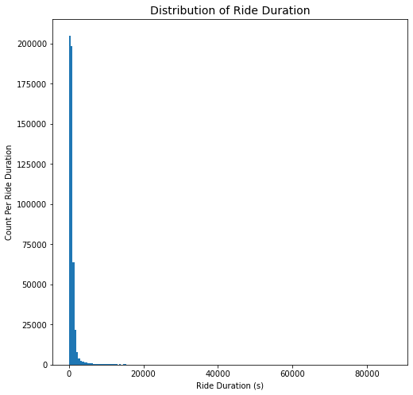

```python
# Plotting a standard histogram of the duration variable
binsize = 500
bins = np.arange(0, df['duration_sec'].max()+binsize, binsize)

plt.figure(figsize=[8, 8])
plt.hist(data = df, x = 'duration_sec', bins = bins)
plt.title('Distribution of Ride Duration', fontsize = 14)
plt.xlabel('Ride Duration (s)', fontsize =10)
plt.ylabel('Count Per Ride Duration', fontsize =10)
plt.show();
```

> The initial standard histogram plot of the duration_sec feature shows that most of the data is set to the far left of the plot axes, suggesting that the duration of most rides fall below 20000 seconds.

```python
np.log10(df.describe())
```

|  | duration_sec | start_station_latitude | start_station_longitude | end_station_latitude | end_station_longitude |
| --- | --- | --- | --- | --- | --- |
| count | 5.715753 | 5.715753 | 5.715753 | 5.715753 | 5.715753 |
| mean | 3.041001 | 1.577166 | NaN | 1.577168 | NaN |
| std | 3.537082 | -1.063964 | -0.976445 | -1.064373 | -0.978306 |
| min | 1.785330 | 1.571910 | NaN | 1.571910 | NaN |
| 25% | 2.582063 | 1.577187 | NaN | 1.577199 | NaN |
| 50% | 2.775246 | 1.577302 | NaN | 1.577306 | NaN |
| 75% | 2.972203 | 1.577439 | NaN | 1.577439 | NaN |
| max | 4.936358 | 1.578413 | NaN | 1.578413 | NaN |

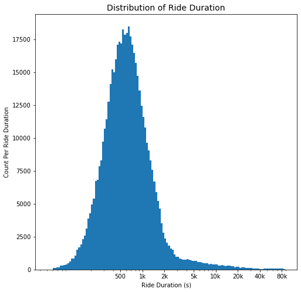

```python
# There's a long tail in the distribution, so will plot the distribution on a log scale instead
log_binsize = 0.025
bins = 10 ** np.arange(1.7, np.log10(df['duration_sec'].max())+log_binsize, log_binsize)

plt.figure(figsize=[8, 8])
plt.hist(data = df, x = 'duration_sec', bins = bins)
plt.title('Distribution of Ride Duration', fontsize = 14)
plt.xscale('log')
plt.xticks([500, 1e3, 2e3, 5e3, 1e4, 2e4, 4e4, 8e4], [500, '1k', '2k', '5k', '10k', '20k', '40k', '80k'])
plt.xlabel('Ride Duration (s)', fontsize =10)
plt.ylabel('Count Per Ride Duration', fontsize =10)
plt.show();
plt.show();
```

> Using a logarithmic scale on the duration variable, it is observed that the distribution is major peaks somewhere between 500 and 1000, after which it declines steadily downwards. The duration distribution also shows most of the data falls to the lest hand side. This suggests that there may be outliers present on the right. These outliers will be identified and possibly filtered out of the data if required.

```python
# Selecting high outliers i.e above 20000
outlier = (df['duration_sec'] > 20000)

print(outlier.sum())
df.loc[outlier,:]
```

```
2549
```

|  | duration_sec | start_time | end_time | start_station_id | start_station_name | start_station_latitude | start_station_longitude | end_station_id | end_station_name | end_station_latitude | end_station_longitude | bike_id | user_type | start_day | start_month | start_hour |
| --- | --- | --- | --- | --- | --- | --- | --- | --- | --- | --- | --- | --- | --- | --- | --- | --- |
| 0 | 80110 | 2017-12-31 16:57:39.654 | 2018-01-01 15:12:50.245 | 74 | Laguna St at Hayes St | 37.776435 | -122.426244 | 43 | San Francisco Public Library (Grove St at Hyde... | 37.778768 | -122.415929 | 96 | Customer | Sunday | December | 16 |
| 1 | 78800 | 2017-12-31 15:56:34.842 | 2018-01-01 13:49:55.617 | 284 | Yerba Buena Center for the Arts (Howard St at ... | 37.784872 | -122.400876 | 96 | Dolores St at 15th St | 37.766210 | -122.426614 | 88 | Customer | Sunday | December | 15 |
| 2 | 45768 | 2017-12-31 22:45:48.411 | 2018-01-01 11:28:36.883 | 245 | Downtown Berkeley BART | 37.870348 | -122.267764 | 245 | Downtown Berkeley BART | 37.870348 | -122.267764 | 1094 | Customer | Sunday | December | 22 |
| 3 | 62172 | 2017-12-31 17:31:10.636 | 2018-01-01 10:47:23.531 | 60 | 8th St at Ringold St | 37.774520 | -122.409449 | 5 | Powell St BART Station (Market St at 5th St) | 37.783899 | -122.408445 | 2831 | Customer | Sunday | December | 17 |
| 4 | 43603 | 2017-12-31 14:23:14.001 | 2018-01-01 02:29:57.571 | 239 | Bancroft Way at Telegraph Ave | 37.868813 | -122.258764 | 247 | Fulton St at Bancroft Way | 37.867789 | -122.265896 | 3167 | Subscriber | Sunday | December | 14 |
| ... | ... | ... | ... | ... | ... | ... | ... | ... | ... | ... | ... | ... | ... | ... | ... | ... |
| 518086 | 25453 | 2017-06-29 13:26:20.870 | 2017-06-29 20:30:34.805 | 17 | Embarcadero BART Station (Beale St at Market St) | 37.792251 | -122.397086 | 67 | San Francisco Caltrain Station 2 (Townsend St... | 37.776639 | -122.395526 | 278 | Customer | Thursday | June | 13 |
| 518507 | 31303 | 2017-06-29 07:19:09.822 | 2017-06-29 16:00:53.004 | 24 | Spear St at Folsom St | 37.789677 | -122.390428 | 24 | Spear St at Folsom St | 37.789677 | -122.390428 | 1040 | Subscriber | Thursday | June | 07 |
| 518582 | 70584 | 2017-06-28 18:21:27.229 | 2017-06-29 13:57:51.620 | 58 | Market St at 10th St | 37.776619 | -122.417385 | 59 | S Van Ness Ave at Market St | 37.774814 | -122.418954 | 599 | Customer | Wednesday | June | 18 |
| 519073 | 21170 | 2017-06-28 17:23:33.996 | 2017-06-28 23:16:24.837 | 14 | Clay St at Battery St | 37.795001 | -122.399970 | 66 | 3rd St at Townsend St | 37.778742 | -122.392741 | 434 | Subscriber | Wednesday | June | 17 |
| 519077 | 25364 | 2017-06-28 15:18:29.503 | 2017-06-28 22:21:13.582 | 28 | The Embarcadero at Bryant St | 37.787168 | -122.388098 | 30 | San Francisco Caltrain (Townsend St at 4th St) | 37.776598 | -122.395282 | 831 | Customer | Wednesday | June | 15 |

2549 rows × 16 columns

```python
# removing identified outliers.

df = df.loc[-outlier,:]
```

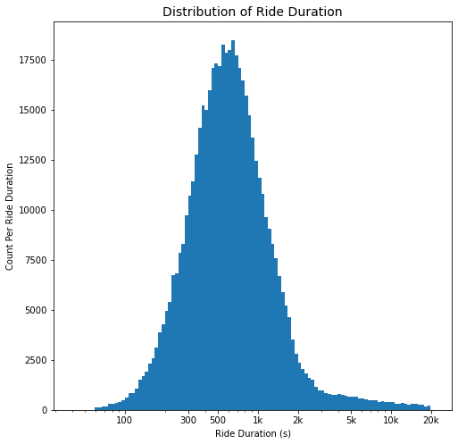

```python
# Setting bin size and bins
log_binsize = 0.025
bins = 10 ** np.arange(1.6, np.log10(df['duration_sec'].max())+log_binsize, log_binsize)

# distribution of ride duration
plt.figure(figsize=[8, 8])
plt.hist(data = df, x = 'duration_sec', bins = bins)
plt.title('Distribution of Ride Duration', fontsize = 14)
plt.xscale('log')
plt.xticks([100, 300, 500, 1e3, 2e3, 5e3, 1e4, 2e4], [100, 300, 500, '1k', '2k', '5k', '10k', '20k'])
plt.xlabel('Ride Duration (s)', fontsize =10)
plt.ylabel('Count Per Ride Duration', fontsize =10)
plt.show();
```

> With the removal of outliers, it can be observed that the distribution of the `duration` variable is similar to that of a normal distribution. The use of a logarithm scale also serves to provide better insight into the count per ride duration and it is seen that the count of shorter ride durations are more than those of longer ride durations.

> Looking at the predictors of interest such as start day, start month and start hour and user type, the distribution of these predictors will be plotted.

### Number of Rides Per Start Hour

This plot aims to show the number of rides taken at each hour of the day thereby highlighting the hour/hours with the highest number of rides taken.

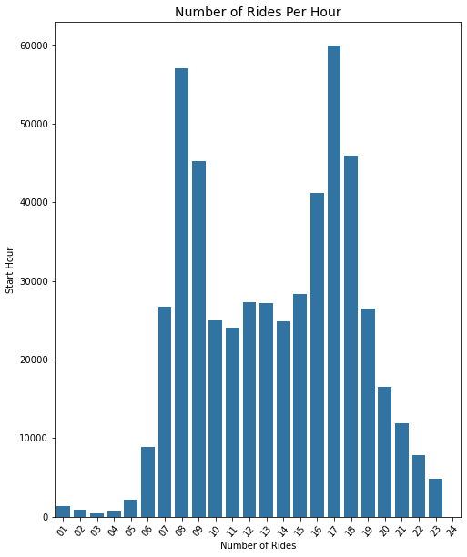

```python
# Setting plot size and base color
plt.figure(figsize = [8, 10])
default_color = sb.color_palette()[0]

# Plotting number of rides per hour
sb.countplot(data = df, x = 'start_hour', color = default_color)
plt.title('Number of Rides Per Hour', fontsize = 14)
plt.xticks(rotation = 50)
plt.xlabel('Number of Rides', fontsize =10)
plt.ylabel('Start Hour', fontsize =10)
plt.show()
```

### Number Of Rides Per Start Day and Month.

These plots aim to show the number of rides taken for each day of the week and for each month. It highlights the day/days of the week and month/months with have the largest number of rides taken.

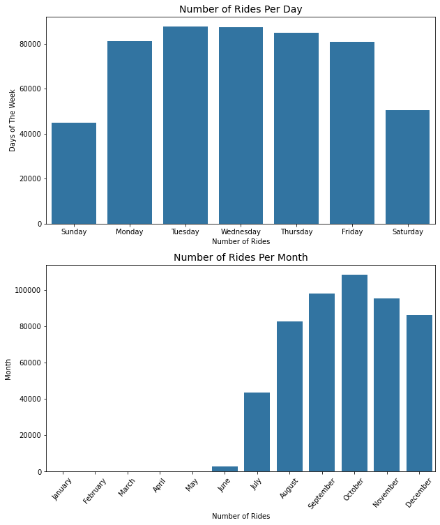

```python
# Setting plot size and base color
fig, ax = plt.subplots(nrows=2, figsize = [10,12])
default_color = sb.color_palette()[0]

# Plotting number of rides per day
sb.countplot(data = df, x = 'start_day', color = default_color, ax = ax[0])
ax[0].set_title('Number of Rides Per Day', fontsize = 14)
ax[0].set_xlabel('Number of Rides', fontsize=10)
ax[0].set_ylabel('Days of The Week', fontsize=10)

# Plotting number of rides per month
sb.countplot(data = df, x = 'start_month', color = default_color, ax = ax[1])
ax[1].set_title('Number of Rides Per Month', fontsize = 14)
ax[1].set_xlabel('Number of Rides', fontsize =10)
ax[1].set_ylabel('Month', fontsize =10)
plt.xticks(rotation = 50)
plt.show()
```

> - For start day, most of the rides are significantly centered around weekdays (Monday, Tuesday, Wednesday, Thursday, Friday) compared to weekends (Saturday, Sunday). Of all the days, Tuesday is seen to have the most rides.
> - For start month it can be seen that no rides were recorded for the month of `January` to `May`. However, rides were recorded from the month of `June` to `December` with `October` recording the highest number of rides.

### Number Of Rides Per User Type

This plot aims to show the different users and the number of rides taken by each thereby highlighting wich user type take more rides.

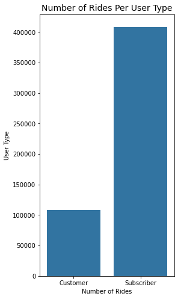

```python
# Setting plot size and base color
plt.figure(figsize = [4,8])
default_color = sb.color_palette()[0]

# Plotting number of rides per user type
sb.countplot(data = df, x = 'user_type', color = default_color)
plt.title('Number of Rides Per User Type', fontsize = 14)
plt.xlabel('Number of Rides', fontsize =10)
plt.ylabel('User Type', fontsize =10)
plt.show();
```

#### Percentage of Users Per User Type

This plot aims to show the percentage distribution of users by the different user types.

```python
# computing the number of users per user type

users = df['user_type'].value_counts()
users = users.reset_index(name = 'no_users').sort_values(by = 'no_users', ascending = False)
```

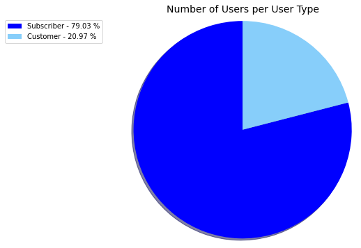

```python
## Adding a legend to the chart and increasing its size
colors = ['blue', 'lightskyblue']
plt.subplots(figsize = [6, 6])

percent = 100.*users.no_users/users.no_users.sum()
patches, texts = plt.pie(users.no_users, colors=colors, startangle=90, radius=1.2, shadow = True)
labels = ['{0} - {1:1.2f} %'.format(i,j) for i,j in zip(users['index'], percent)]

sort_legend = True
if sort_legend:
    patches, labels, dummy =  zip(*sorted(zip(patches, labels, users.no_users),
                                          key=lambda x: x[2],
                                          reverse=True))

plt.legend(patches, labels, loc='upper right', bbox_to_anchor=(-0.1, 1.),
           fontsize=10)
plt.title('Number of Users per User Type', fontsize = 14);
```

> With only two unique values in the nominal user_type variable, users who are `Subscribers` are significantly more than those who are customers. This can be seen in the chart above.

### Number Of Rides For Top 10 Start Stations.

This plot aims to show the top 10 start staions with the highest number of rides taken thereby highlighting the start station with the highest number of rides.

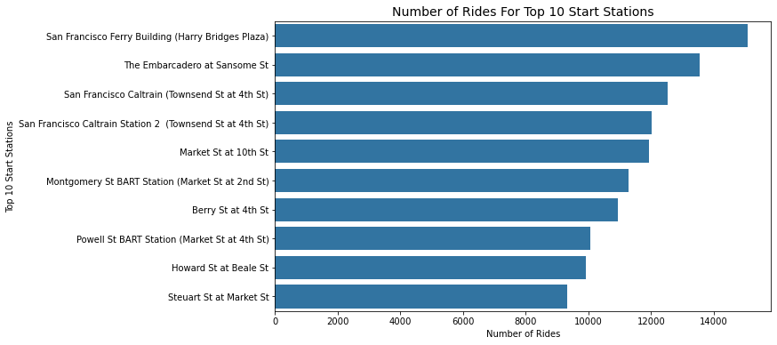

```python
# Setting the plot size and base color
plt.figure(figsize = [10, 6])
base_color = sb.color_palette()[0]

# Number of rides per top 10 start station
start_station_order = df['start_station_name'].value_counts().sort_values(ascending = False).index

# Plot of the top 10 start stations
sb.countplot(data = df, y = 'start_station_name', color = base_color, order = start_station_order[:10], orient = 'h')
plt.title('Number of Rides For Top 10 Start Stations', fontsize = 14)
plt.xlabel('Number of Rides', fontsize=10)
plt.ylabel('Top 10 Start Stations', fontsize=10)
plt.show();
```

> From the chart above it can be seen that the largest number of rides were taken at `San Francisco Ferry Building (Harry Bridges Plaza)`.

### Of the features you investigated, were there any unusual distributions? Did you perform any operations on the data to tidy, adjust, or change the form of the data? If so, why did you do this?

> When investigating the duration variable, a number of outliers were identified and removed from the dataset to aid accurate analysis and visualisation.

## Bivariate Exploration

> This involves investigating relationships between pairs of variables in the data.

### Ride Duration Per Start Day, Hour, Month and User Type

These box plots aim to give a better insight into the interaction of ride duration with start day, hour, month and user type to answer questions like:

- What month/months has the longest ride duration?
- Which user type has longer ride duration?
- Which day/days of the week have longer ride durations?
- Which hour/hours of the day do longer ride durations occur?

```python
# Assist function for creating plots showing the relationship
# between ride duration and other variables(start day, hour, month and user type)

def box_plots(var, color):
    fig, ax = plt.subplots(figsize = [8,4])
    sb.boxplot(data = df, y ='duration_sec', x = var, ax = ax,
                  color = color)
    ax.set_ylabel("Ride Duration (s)", fontsize=10)
    ax.set_xlabel(var.capitalize(), fontsize=10)
    plt.xticks(rotation=50)
    fig.suptitle('Ride Duration Per {}'.format(var.capitalize()), fontsize=14)
    plt.show()
```

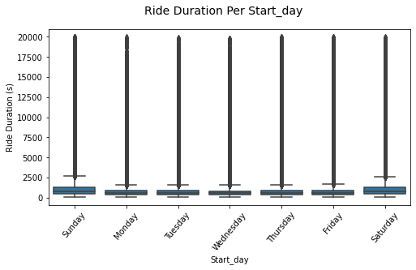

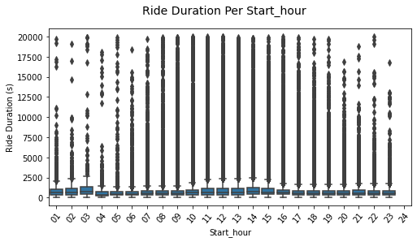

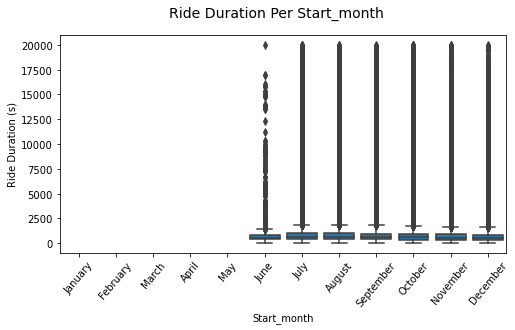

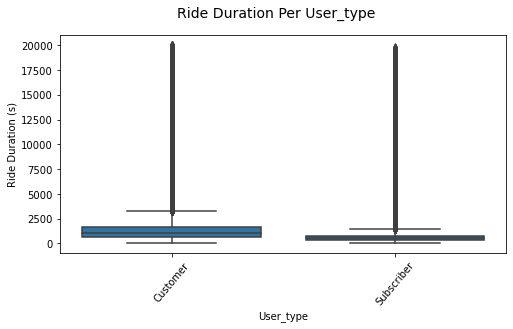

```python
box_plots('start_day', sb.color_palette()[0])
box_plots('start_hour', sb.color_palette()[0])
box_plots('start_month', sb.color_palette()[0])
box_plots('user_type', sb.color_palette()[0])
```

> - From the plots of the categorical variables against the duration in seconds, it is observed that multiple duration outliers are present across the day, month and hour variables.
> - Despite the presence of very large outliers, the median duration across start day, month, hour and user type variables falls below 2500 seconds.
> - Based on the median duration rides taken on weekends (Saturday and Sunday) are seen to be longer compared to other days of the week.

> Due to the extremely large values of ride duration, a logarithmic transformation of the duration in seconds will be computed and used in plotting.

#### Log Average Duration Per Start Day, Hour, Month and User Type

```python
# computing the logarithm of price to make plotting easier

def log_trans(x, inverse = False):
    """ quick function for computing log and power operations """
    if not inverse:
        return np.log10(x)
    else:
        return np.power(10, x)

df['log_duration'] = df['duration_sec'].apply(log_trans)
```

```python
# Assist function for creating plots showing the relationship
# between ride duration and other variables(start day, hour, month and user type)

def violin_plot(var, color):
    fig, ax = plt.subplots(figsize = [10,6])
    sb.violinplot(data = df, y ='log_duration', x = var, ax = ax,
                  color = color)
    ax.set_yticks(log_trans(np.array([50, 250, 500, 1e3, 2e3, 5e3, 1e4, 2e4])))
    ax.set_yticklabels([50, 250, 500, '1k', '2k', '5k', '10k', '20k'])
    ax.set_ylabel("Ride Duration (s)", fontsize=10)
    ax.set_xlabel(var.capitalize(), fontsize=10)
    plt.xticks(rotation=50)
    fig.suptitle('Ride Duration Per {}'.format(var.capitalize()), fontsize=14)
    plt.show()
```

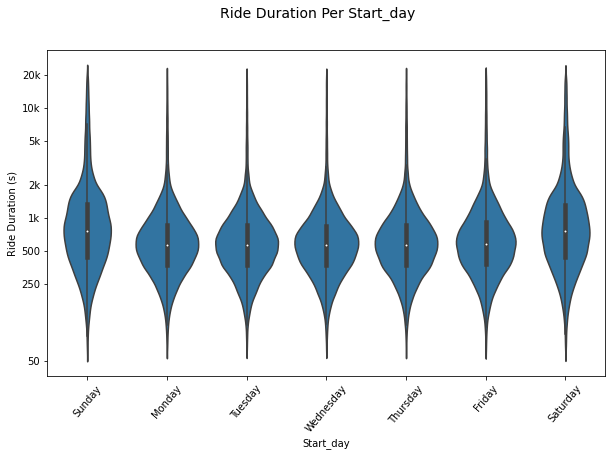

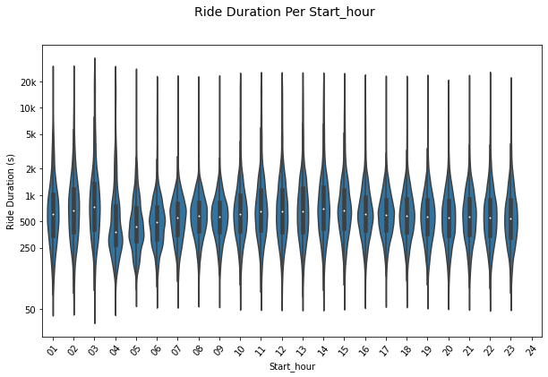

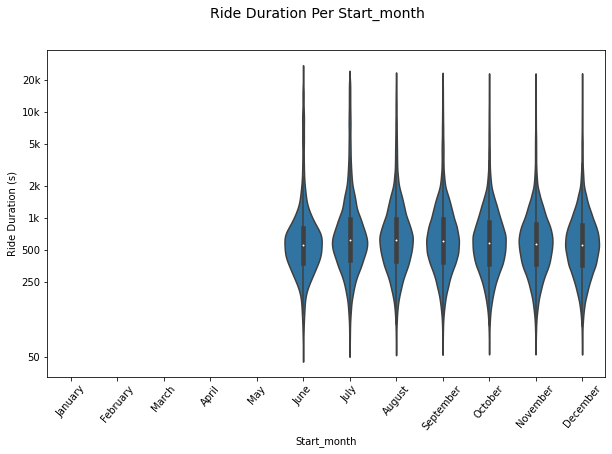

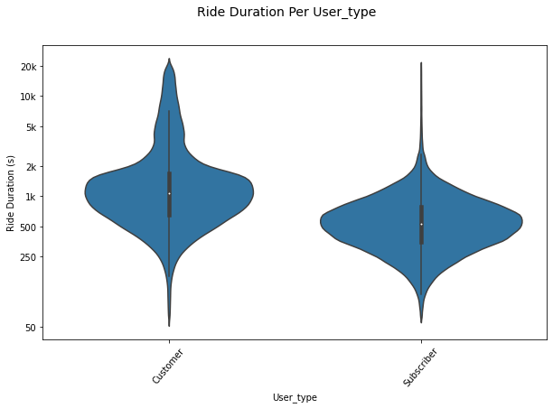

```python
# applying plotting function to show plots

violin_plot('start_day', sb.color_palette()[0])
violin_plot('start_hour', sb.color_palette()[0])
violin_plot('start_month', sb.color_palette()[0])
violin_plot('user_type', sb.color_palette()[0])
```

> Using a violin plot and duration transformation on the entire data a better insight into the average ride duration across start month, say, hour and user type is seen. The difference in the ride duration during weekdays or weekends may be affected by the user type, start hour of start month of the ride. The effect of these categories across each other on the ride duration will be seen in the multivariate analysis. It can also be seen that the median ride duration was higher for customers, and weekends (`Saturday` and `Sunday)`. The median ride duration was also higher between `01:00`am and `03:00`am and almost equal for the months of `July`, `August`, `September`, `October` and `November`.

### Plots of variability between categorical variables

These countplots aims to look at the level of interaction amongst start day, hour, month and user type with each other.

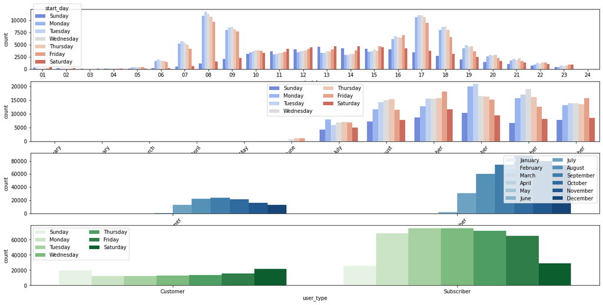

```python
# Setting plot size
plt.figure(figsize = [20, 10])

# subplot 1: start hour vs. start day
plt.subplot(4, 1, 1)
sb.countplot(data = df, x = 'start_hour', hue = 'start_day', palette = 'coolwarm')

# subplot 2: # subplot 3: start month vs. start day
ax = plt.subplot(4, 1, 2)
sb.countplot(data = df, x = 'start_month', hue = 'start_day', palette = 'coolwarm')
plt.xticks(rotation =50)
ax.legend(ncol = 2)

# subplot 3: user type vs. start month
ax = plt.subplot(4, 1, 3)
sb.countplot(data = df, x = 'user_type', hue = 'start_month', palette = 'Blues')
plt.xticks(rotation =50)
ax.legend(loc = 1, ncol = 2)

# subplot 4: user type vs. start day
ax = plt.subplot(4, 1, 4)
sb.countplot(data = df, x = 'user_type', hue = 'start_day', palette = 'Greens')
ax.legend(loc = 2, ncol = 2)
plt.show()
```

### Talk about some of the relationships you observed in this part of the investigation. How did the feature(s) of interest vary with other features in the dataset?

> The duration of the ride has a varied relationship with the start day, hour and user type.
> - Longer rides are observed during the weekends(Saturday and Sunday) than weekends.
> - Customers engage in longer rides compared to subscribers despite the latter engaging in more rides compared to the former. This can be compared using the usertype univariate plot and log duration bivariate plot.
> - Ride duration varied with the hour with the shortest ride durations occuring between 4th and 6th hour(04:00 am to 06:00 am).

### Did you observe any interesting relationships between the other features (not the main feature(s) of interest)?

> Expected relationships were also found between start day, hour, month and user types.
> - The subscribers are seen to have a large number of rides compared to the consumers across all months and days of the week.
> - The number of rides varied across startday per month and start day per hour.

## Multivariate Exploration

> Plots of three or more variables are created to investigate the how the categorical variables of day, month hour and user type define the duration of rides taken.

### Ride Duration by Start Month, Date and Hour Per User Type.

This plot aims to measure the ride duration per user type across all months, hours of the day and days of the week. The question to be answered is:

- Which users take longer rides regardless of the day, hour and month?

```python
# Assist function for creating plots showing the relationship
# between ride duration and other variables(start day, hour and month) per user type

def box_plot(var, hue):
    fig, ax = plt.subplots(figsize = [10,6])
    sb.boxplot(data = df, x = var, y = 'log_duration',
           hue = hue, ax = ax)
    ax.set_yticks(log_trans(np.array([50, 250, 500, 1e3, 2e3, 5e3, 1e4, 2e4])))
    ax.set_yticklabels([50, 250, 500, '1k', '2k', '5k', '10k', '20k'])
    ax.set_ylabel("Ride Duration (s)")
    ax.set_xlabel(var.capitalize())
    ax.set_yticklabels([],minor = True)
    ax.legend(loc = 6, bbox_to_anchor = (1.0, 0.5))
    plt.xticks(rotation=50)
    fig.suptitle('Ride Duration Per {} Per {}'.format(var.capitalize(), hue.capitalize()), fontsize=14)
    plt.show()
```

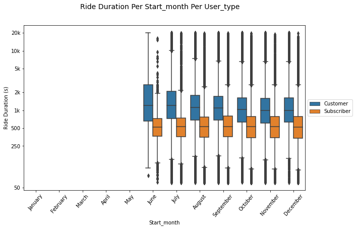

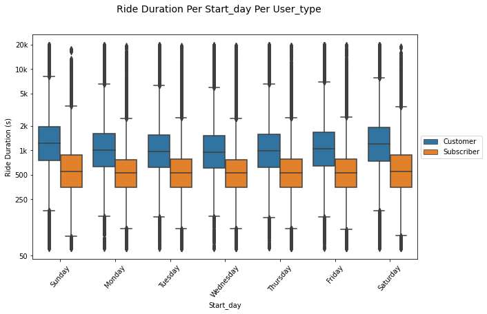

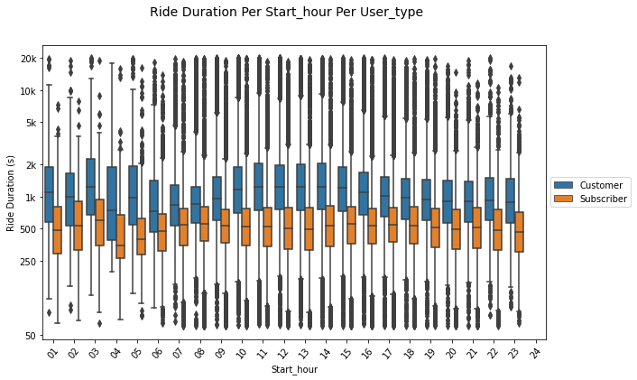

```python
box_plot('start_month', 'user_type')
box_plot('start_day', 'user_type')
box_plot('start_hour', 'user_type')
```

### Ride Duration by Start Month and Hour Per Day

This plot aims to measure the ride duration per day across all months and hours of the day. The question to be answered is:

- What day of the week are longer rides taken across all months and hours of the day?

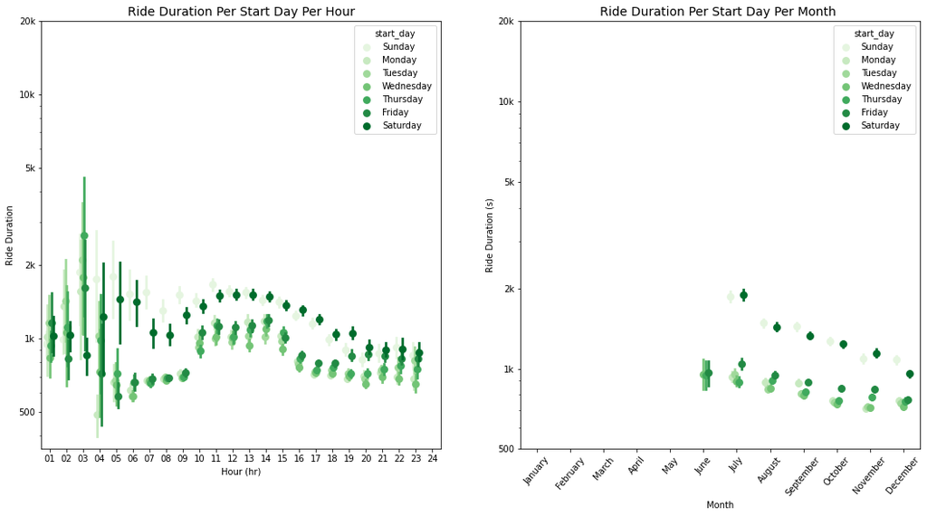

```python
# Setting the plot sizes
fig, ax = plt.subplots(ncols = 2, figsize = [18,9])

# Subplot 1 : start day and hour vs duration
sb.pointplot(data = df, x = 'start_hour', y = 'duration_sec', hue = 'start_day',
           palette = 'Greens', linestyles = '', dodge = 0.4, ax = ax[0])
ax[0].set_title('Ride Duration Per Start Day Per Hour', fontsize =14)
ax[0].set_ylabel('Ride Duration', fontsize =10)
ax[0].set_xlabel('Hour (hr)')
ax[0].set_yscale('log')
ax[0].set_yticks([500, 1e3, 2e3, 5e3, 1e4, 2e4])
ax[0].set_yticklabels([500, '1k', '2k', '5k', '10k', '20k'])
ax[0].set_yticklabels([],minor = True)

# Subplot 2 : start day and month vs duration
sb.pointplot(data = df, x = 'start_month', y = 'duration_sec', hue = 'start_day',
           palette = 'Greens', linestyles = '', dodge = 0.4, ax = ax[1])
ax[1].set_title('Ride Duration Per Start Day Per Month ', fontsize = 14)
ax[1].set_xlabel('Month', fontsize = 10)
ax[1].set_ylabel('Ride Duration (s)', fontsize = 10)
ax[1].set_yscale('log')
ax[1].set_yticks([500, 1e3, 2e3, 5e3, 1e4, 2e4])
ax[1].set_yticklabels([500, '1k', '2k', '5k', '10k', '20k'])
ax[1].set_yticklabels([],minor = True)
plt.xticks(rotation = 50)


plt.show();
```

> The variation and hierachy in the ride duration across the start month and hour for all the days of the week shows that longer rides are usually taken on weekends (`Saturday` and `Sunday`) per month and hour.

### Ride Duration by Top 10 Start Station Per User.

This plot aims to measure the average ride duration at the top 10 start stations by different users. The questions to be answered are:

- Which users take longer rides at each of these start stations?
- Which start stations have the longest rides taken by users?

```python
# Extracting the top 10 start stations with the highest average duration
top_start_stations = df.start_station_name.value_counts()[:10].index
top10_station = df[df.start_station_name.isin(top_start_stations)].copy()

top10_station.head()
```

|  | duration_sec | start_time | end_time | start_station_id | start_station_name | start_station_latitude | start_station_longitude | end_station_id | end_station_name | end_station_latitude | end_station_longitude | bike_id | user_type | start_day | start_month | start_hour | log_duration |
| --- | --- | --- | --- | --- | --- | --- | --- | --- | --- | --- | --- | --- | --- | --- | --- | --- | --- |
| 5 | 9226 | 2017-12-31 22:51:00.918 | 2018-01-01 01:24:47.166 | 30 | San Francisco Caltrain (Townsend St at 4th St) | 37.776598 | -122.395282 | 30 | San Francisco Caltrain (Townsend St at 4th St) | 37.776598 | -122.395282 | 1487 | Customer | Sunday | December | 22 | 3.965013 |
| 12 | 2183 | 2017-12-31 23:52:55.581 | 2018-01-01 00:29:18.743 | 67 | San Francisco Caltrain Station 2 (Townsend St... | 37.776639 | -122.395526 | 24 | Spear St at Folsom St | 37.789677 | -122.390428 | 2311 | Subscriber | Sunday | December | 23 | 3.339054 |
| 13 | 2170 | 2017-12-31 23:52:55.937 | 2018-01-01 00:29:06.924 | 67 | San Francisco Caltrain Station 2 (Townsend St... | 37.776639 | -122.395526 | 24 | Spear St at Folsom St | 37.789677 | -122.390428 | 3717 | Subscriber | Sunday | December | 23 | 3.336460 |
| 21 | 4174 | 2017-12-31 22:52:22.286 | 2018-01-01 00:01:56.614 | 30 | San Francisco Caltrain (Townsend St at 4th St) | 37.776598 | -122.395282 | 6 | The Embarcadero at Sansome St | 37.804770 | -122.403234 | 809 | Customer | Sunday | December | 22 | 3.620552 |
| 27 | 862 | 2017-12-31 23:38:24.874 | 2017-12-31 23:52:47.542 | 6 | The Embarcadero at Sansome St | 37.804770 | -122.403234 | 15 | San Francisco Ferry Building (Harry Bridges Pl... | 37.795392 | -122.394203 | 533 | Customer | Sunday | December | 23 | 2.935507 |

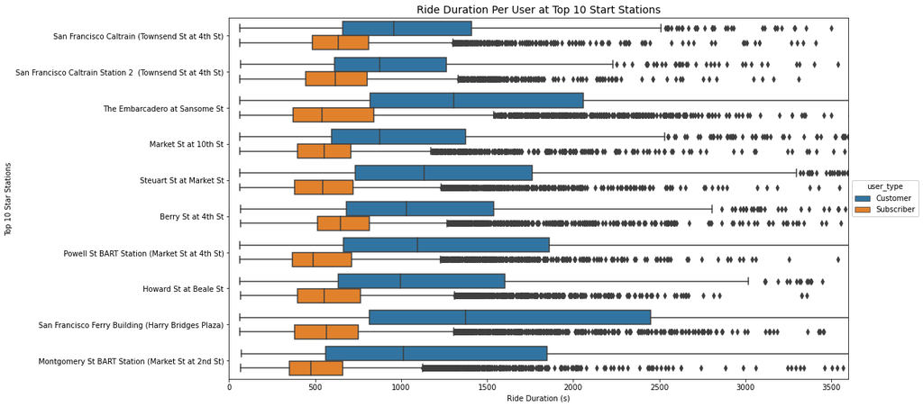

```python
# Setting the plot size and base color
plt.figure(figsize = [15, 9])
base_color = sb.color_palette()[0]

# Plotting top 10 start station per number of rides per user
ax = sb.boxplot(data = top10_station, x = 'duration_sec', y = 'start_station_name', hue = 'user_type', orient = 'h')
ax.legend(loc = 6, bbox_to_anchor = (1.0, 0.5), ncol = 1, framealpha = 1, title = 'user_type')
ax.set_title('Ride Duration Per User at Top 10 Start Stations', fontsize =14)
ax.set_ylabel('Top 10 Star Stations', fontsize =10)
ax.set_xlabel('Ride Duration (s)', fontsize =10)
ax.set_xlim(0, 3600)
plt.show();
```